# Spectral data dimensionality reduction and clustering

Guy Maskall

February 28, 2017

# Introduction

Spectroscopy data are high-dimensional, depending on wavelength range and sampling interval. Visualizing the data, let alone extracting meaningful structure, is a challenge. Firstly, what do we mean by “meaningful structure”? We’ll argue here that such structure should meet the three minimum requirements of:

1. maximizing the amount of useful information
2. providing meaningful group labels
3. using a minimal set of features.

If we took only the first two requirements, we could satisfy them by keeping the full dimensionality spectra and going through one-by-one assigning each to a group. This, however, runs the risk that our groups are not justified by the data. It also performs no dimensionality reduction, meaning much redundant data will be retained. Can we then, in a **data driven** way, extract meaningful features and be guided toward a useful grouping of spectra?

For this example, we gathered together some data that included a variety of petrol and diesel and concentrations of ethanol. We show that the majority of structure present in the high-dimensional spectral data can be represented using just a small number of features that both reflect differences within the categories and are amenable to a meaningful grouping.

# Data input

Firstly, there is the task of reading in the data. In this case, the data had been previously processed in batches (by material type and originating spectrometer system) and various stages of processed output saved as matrices within a list. This is a convenient way of keeping together processed data and any desired metadata such as the name of the material being measured.

```r
library(dplyr)
```

```r
library(ggplot2)

# define a function to handle extracting the required matrix
# this reads in a single file containing an R list object,
# from which we extract the specNew matrix and name the
# rows according to the material name (this will facilitate
# the combination of each file contents and subsequent analysis).
extract_spec_matrix <- function(filename) {
    load(filename)
    spec <- spectra$specNew
    rownames(spec) <- spectra$contents.name
    return(spec)
}

# loading the data
# get the list of files we wish to read
files <- Sys.glob("example_data/*spec*Clearglass.dat")

#illustrate structure of data object
load(files[1])
class(spectra)
```

```
## [1] "list"
```

```r
str(spectra)
```

```
## List of 15
##  $ class         : num 1004
##  $ container.name: chr [1:10] "Clear glass" "Clear glass" "Clear glass" "Clear glass" ...
##  $ machine       : chr [1:10] "20006" "20006" "20006" "20006" ...
##  $ specMax       : num [1:10] 25307 25326 25103 25064 24824 ...
##  $ scans         : int [1:10] 2587 2590 2593 2596 2599 2602 2605 2608 2611 2614
##  $ xaxis         : int [1:1801] 200 201 202 203 204 205 206 207 208 209 ...
##  $ spec          : num [1:10, 1:1801] 0 0 0 0 0 0 0 0 0 0 ...
##  $ zero          : num [1:10, 1:1801] 9554 9536 9436 9433 9356 ...
##  $ zeroB         : num [1:10, 1:1801] -15.65 42.326 -0.266 3.083 -20.95 ...
##  $ offset        : num [1:10, 1:1801] 194436 193183 192411 187236 189055 ...
##  $ offsetB       : num [1:10, 1:1801] -290 -306 -269 -279 -384 ...
##  $ specNew       : num [1:10, 1:1801] -16.3 -34.31 3.65 -34.43 4.12 ...
##  $ zeroBNew      : num [1:10, 1:1801] -9.56 47.5 -3.05 2.25 5.62 ...
##  $ offsetBNew    : num [1:10, 1:1801] -17.02 -30.13 3.42 -34.27 4.68 ...
##  $ contents.name : chr [1:10] "dieselsummer" "dieselsummer" "dieselsummer" "dieselsummer" ...
```

```r
# notice a load of 10x1801 matrices of spectra and, in particular, associated
# content label for each one (each row)

# iterate over all files and concatenate all the matrices into one
# lapply gives us a list of matrices which we can then pass
# to do.call to be rbind'd together
speclist <- lapply(files, extract_spec_matrix)
spec_matrix <- do.call(rbind, speclist)
# now we've gathered all our spectra into a single matrix
contents <- rownames(spec_matrix)
print(table(contents))
```

```
## contents
##             acetone        dieselsummer        dieselwinter
##                  60                  90                  90
##             ethanol         ethanol10pc         ethanol15pc
##                  90                  90                  90
##         ethanol40pc         ethanol50pc         ethanol60pc
##                  90                  90                  90
##         ethanol80pc                 ipa    keroseneparaffin
##                  90                  90                  90
##            methanol              petrol premiumdieselsummer
##                  90                  90                  90
##       premiumpetrol   trichloroethylene
##                  90                  90
```

```r
# describe briefly the contents
```

We have now neatly read in all the data, for the named materials, from multiple files and combined into a single matrix with each row being a (high dimensional) spectrum with the rowname describing what it represents. There is a mix of various petrols, diesels, alcohols, and a few others.

# Visualization

What do our data look like? There are a lot of observations, so let’s look at the average spectrum for each.

```r
group_means <- by(spec_matrix, contents, colMeans)
class(group_means)
```

```
## [1] "by"
```

```r
num_groups <- length(group_means)
print(num_groups)
```

```
## [1] 17
```

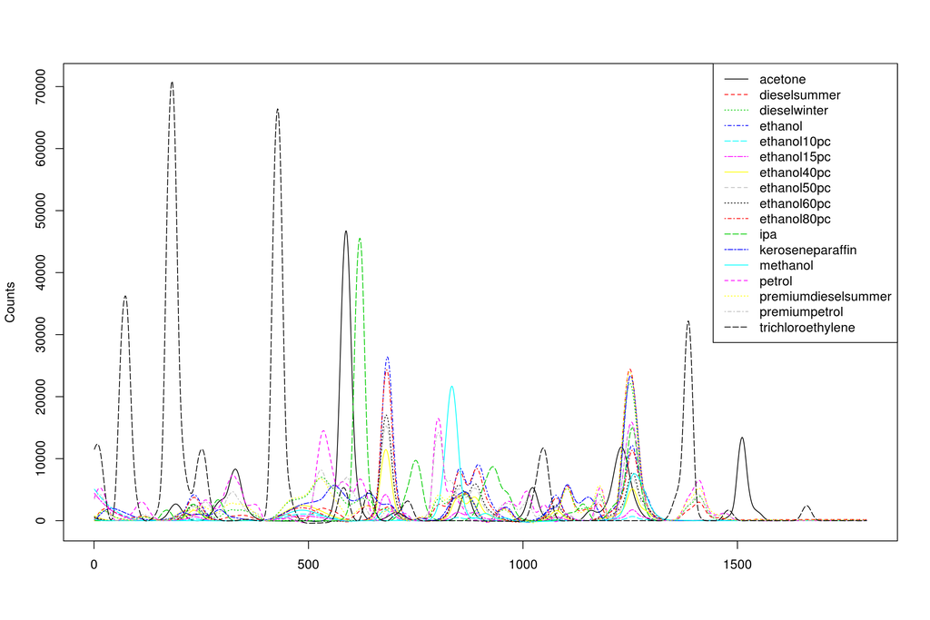

```r
# you can also pass an object of type 'by' to do.call!
group_means <- do.call(rbind, group_means)
group_names <- rownames(group_means)
matplot(t(group_means), type = "l", col = 1:num_groups, lty = 1:num_groups, ylab = "Counts")
legend("topright", group_names, col = 1:num_groups, lty = 1:num_groups)
```

Clearly there are a couple of issues with this visualization. Firstly, the spectra are quite complex and it will be very difficult to gather them together into similar groups based on this plot. Secondly, the amplitudes vary considerably; some differences will be due to instrument measurement settings, but some materials simply have stronger (brighter) spectra than others. This also suggests an issue with the averaging by contents name; we really want to correct for amplitude from each system before averaging. We’ll now go back and normalize each spectrum and recalculate the averages. Note that, in this application domain, we know that our spectra will sit on a y-intercept of zero, so we only want to normalize for amplitude.

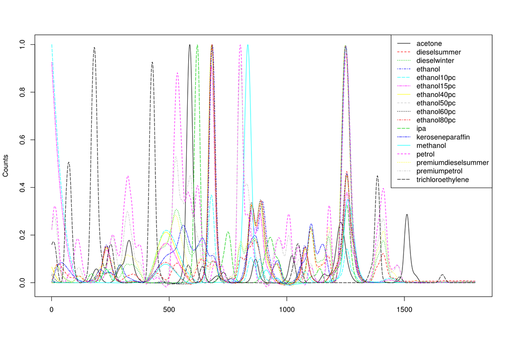

```r
spec_matrix <- t(apply(spec_matrix, 1, function(x) x/max(x)))
group_means <- by(spec_matrix, contents, colMeans)
group_means <- do.call(rbind, group_means)
matplot(t(group_means), type = "l", col = 1:num_groups, lty = 1:num_groups, ylab = "Counts")
legend("topright", group_names, col = 1:num_groups, lty = 1:num_groups)
```

Now that we’ve normalized the amplitude scale, we do get a better view of the spectra, but it would still be a difficult task to compare all the various bands to try to judge similarity. So now we’ll turn to Principle Components Analysis (PCA) to try to get a parsimonious description of the data that we can start to make sense of.

# Feature extraction

We’ll now run PCA on the matrix of normalized spectra.

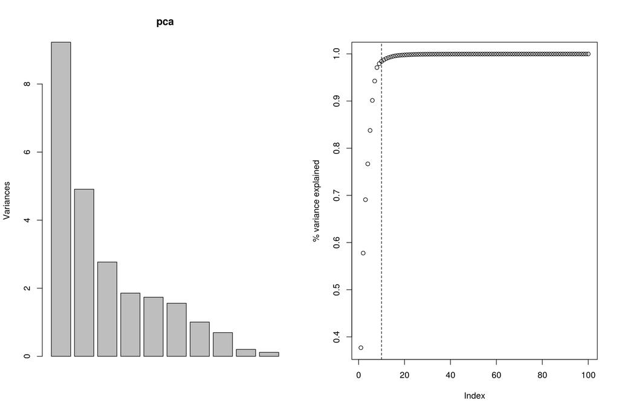

```r
pca <- prcomp(spec_matrix)

par(mfrow = c(1, 2))
plot(pca)
with(pca, plot(cumsum(sdev[1:100]^2)/sum(sdev^2), ylab = "% variance explained"))
abline(v = 10, lty = 2)
```

```r
with(pca, cumsum(sdev[1:10]^2)/sum(sdev^2))
```

```
##  [1] 0.3770778 0.5776890 0.6908999 0.7667598 0.8376705 0.9013717 0.9424602
##  [8] 0.9709195 0.9792275 0.9839743
```

```r
# so it looks like 10 components captures 98% of the variance, let's start
# encapsulating that into a data frame
spectra <- bind_cols(as.data.frame(contents, stringsAsFactors = FALSE), as.data.frame(pca$x[, 1:10]))
head(spectra[, 1:3])
```

```
##       contents      PC1        PC2
## 1 dieselsummer 1.601657 -0.3429275
## 2 dieselsummer 1.589151 -0.4564401
## 3 dieselsummer 1.800228 -0.4181109
## 4 dieselsummer 1.560229 -0.4182505
## 5 dieselsummer 1.610220 -0.3554358
## 6 dieselsummer 1.524221 -0.3685042
```

```r
# Having the contents name as a variable allows us to easily perform further manipulation anyway.
```

PCA tells us that we can explain 98% of the variance in the data using the first ten principal components, and this seems a reasonable cut off; beyond these ten components there is very little benefit in adding futher components. A great thing about these components is that we can also see that 58% of the variance is captured in the first two components, and two components are readily visualized in a plot!

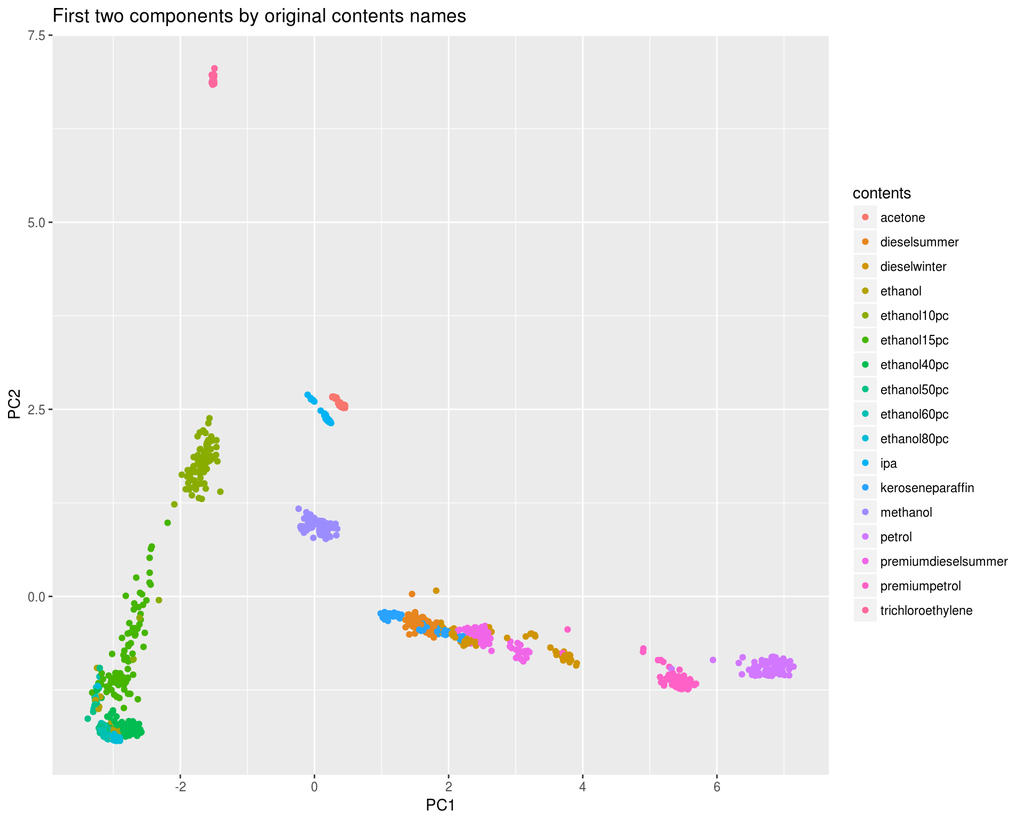

```r
g1 <- ggplot(spectra) +
        geom_point(aes(x = PC1, y = PC2, colour = contents)) +
        labs(title = "First two components by original contents names")
print(g1)
```

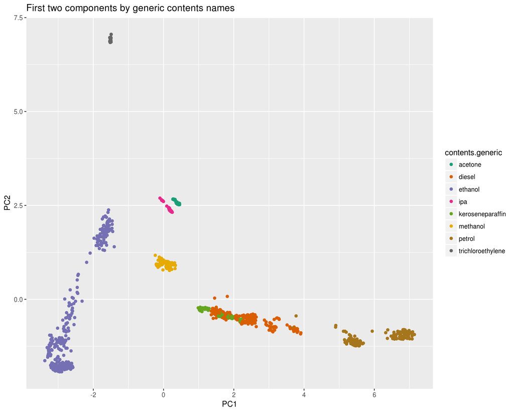

```r
# add manual group labels, so gather together the petrols and the diesels, regardless of
# whether they are summer or winter mix or premium, but keep that additional information
# in another variable (contents.generic.2)
spectra <- spectra %>%
                mutate(contents.generic = ifelse(grepl("diesel", contents), "diesel",
                                            ifelse(grepl("petrol", contents), "petrol",
                                            ifelse(grepl("^ethanol", contents), "ethanol", contents)))) %>%
                mutate(contents.generic.2 = ifelse(contents.generic == "petrol", sub("petrol", "", contents),
                                            ifelse(contents.generic == "diesel", sub("diesel", "", contents),
                                            ifelse(contents.generic == "ethanol", sub("ethanol", "", contents), "")))) %>%
                mutate(contents.generic.2 = ifelse(contents.generic.2 == "", "pure", contents.generic.2))

g2 <- ggplot(spectra) +
        geom_point(aes(x = PC1, y = PC2, colour = contents.generic)) +
        labs(title = "First two components by generic contents names") +
        scale_colour_brewer(palette = "Dark2")
print(g2)
```

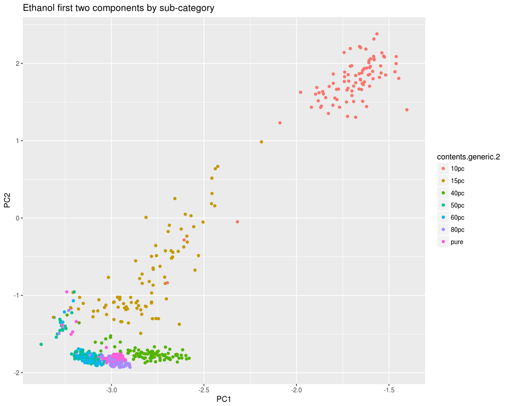

```r
# check out ethanol alone
g3 <- ggplot(filter(spectra, contents.generic == "ethanol")) +
        geom_point(aes(x = PC1, y = PC2, colour = contents.generic.2)) +
        labs(title = "Ethanol first two components by sub-category")
print(g3)
```

These visualizations show us that there is meaningful grouping evident using a reduced-dimensionality description of the data; the petrols lie relatively close together; the diesels, similarly; the ethanols form an interpretable trend of generally increasing concentration from 10% up to pure; interestingly, and unsurprisingly with domain knowledge, the kerosene/paraffin cluster lies close to that of diesel.

# Clustering

Even so, there are limitations to the above visualizations. The first two principal components alone will not reflect the full relationships between the groups of material. According to the first two components, we should contemplate assigning acetone and isopropyl alcohol (ipa) to the same group before we could justify placing standard petrol (petrol) and premium petrol (premiumpetrol) in the same group. One would hope there is structure in the remaining (eight) dimensions that further separates acetone and isopropyl alcohol whilst keeping the petrols close together, for example.

Now we’ll demonstrate the use of hiearchical cluster analysis for further interpreting, and guiding, an analysis of the similarities between the spectra with a view to assigning them to groups. We will compare doing this both on the full-dimensional spectra and using the first ten principal components.

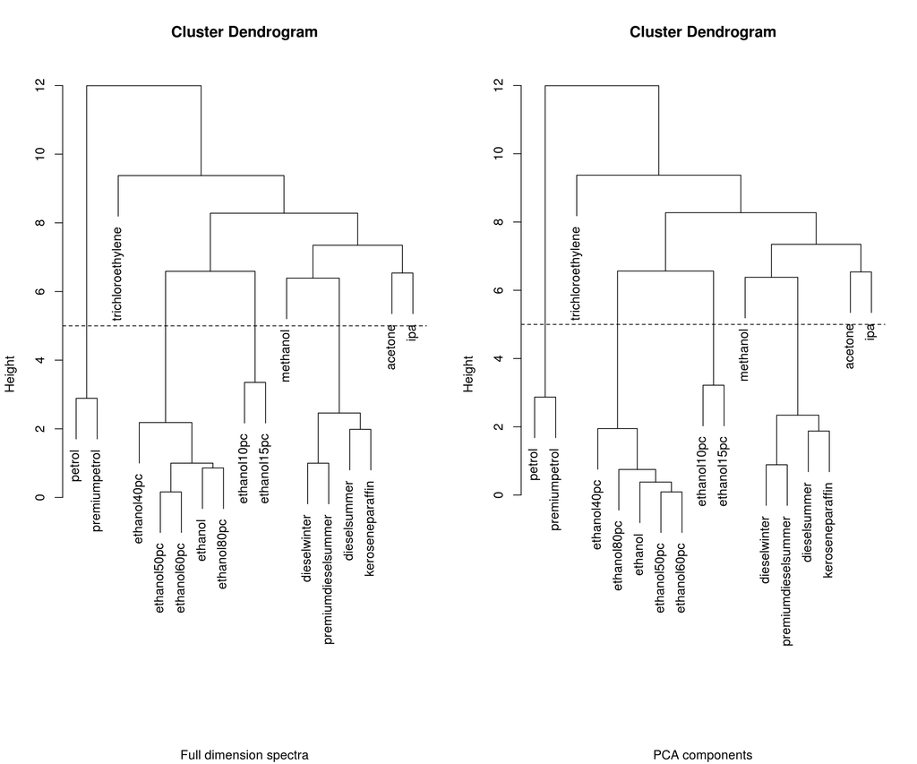

```r
# Can we perform meaningful clustering
# using full-dimension spectra?
# Calculate mean spectra for each content
content_means <- by(spec_matrix, spectra$contents, colMeans)
content_means <- do.call(rbind, content_means)
means_dist <- dist(content_means)
means_hclust <- hclust(means_dist)


# using principal components?
# Calculate mean spectra for each content
reduced_means <- by(spectra[, paste0("PC", 1:10)], spectra$contents, colMeans)
reduced_means <- do.call(rbind, reduced_means)
red_means_dist <- dist(reduced_means)
red_means_hclust <- hclust(red_means_dist)
par(mfrow = c(1, 2))
#compare side by side
plot(means_hclust, sub = "Full dimension spectra", xlab = "")
abline(h = 5, lty = 2)
plot(red_means_hclust, sub = "PCA components", xlab = "")
abline(h = 5, lty = 2)
```

The above side-by-side comparison of the trees show them to be almost the same as each other. This is not altogether very surprising, given that the principal components explained 98% of the variance in the original data, but it is reassuring to see it reflected in the clustering. We can see the petrols hanging together; the ethanols hanging together, with a split between strong and weak concentrations; and the diesels and kerosene/paraffin clustering together, with sub-clustering of summer diesel with kerosene/paraffine and winter diesel with premium summer diesel. The latter observation is interesting. Whilst there are probably a number of compositional differences, this is consistent with paraffin being particularly problematic for waxing in cold temperatures and so being less present in the winter mix.

By drawing a line at a tree height of 5 we see this cuts the tree giving us clusters for petrol, trichloroethylene, strong ethanol, weak ethanol, methanol, light fuel oil, acetone, and ipa thus:

```r
groups_h5 <- cutree(red_means_hclust, h = 5)
groups_h5_df <- data.frame(contents = names(groups_h5), group = groups_h5, stringsAsFactors = FALSE)
groups_h5_df %>% arrange(group)
```

```
##               contents group
## 1              acetone     1
## 2         dieselsummer     2
## 3         dieselwinter     2
## 4     keroseneparaffin     2
## 5  premiumdieselsummer     2
## 6              ethanol     3
## 7          ethanol40pc     3
## 8          ethanol50pc     3
## 9          ethanol60pc     3
## 10         ethanol80pc     3
## 11         ethanol10pc     4
## 12         ethanol15pc     4
## 13                 ipa     5
## 14            methanol     6
## 15              petrol     7
## 16       premiumpetrol     7
## 17   trichloroethylene     8
```

```r
# add the group labels to the original data frame (one row per spectrum),
# joining on content name, to assign each spectrum to a group
spectra <- left_join(spectra, groups_h5_df) # common variable = contents
# label these groups
group_key <- data.frame(group = 1:8,
                        label = c("acetone",
                                  "light oil",
                                  "strong ethanol",
                                  "weak ethanol",
                                  "isopropyl alcohol",
                                  "methanol",
                                  "petrol",
                                  "trichloroethylene"))

# and add these labels to the spectra data.frame
spectra <- left_join(spectra, group_key)
```

The final clustering can be viewed on our previous plot of the first two principal components:

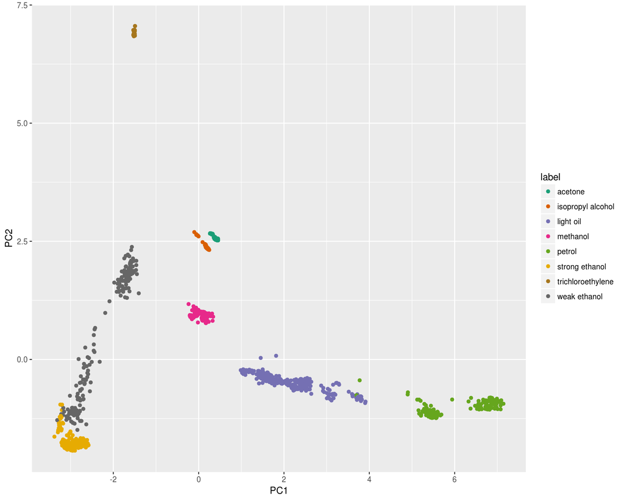

```r
g4 <- ggplot(spectra) +
        geom_point(aes(x = PC1, y = PC2, colour = label)) +
        scale_colour_brewer(palette = "Dark2")
print(g4)
```

# Summary

In this short note we have demonstrated using R to read in, and concatenate, data from multiple files, perform principal components analysis to reduce the dimensionality from 1801 to 10, and then perform hierarchical clustering to inform a data-driven, and interpretable, grouping of the data.